# figures.R

fetz

Sat Aug 5 21:25:14 2017

```r
library(knitr)
library(rgl)
setupKnitr()
library(pca3d)
knit_hooks$set(webgl = hook_webgl)
```

```r
name_key <- read.table("~/ssd/anisha/phage_names.csv", sep = "\t", header = T)

colnames(name_key)[1] <- "phage"

eop <- read.table("~/ssd/anisha/eop_values.csv", header = T, sep = "\t")

eop <- eop[!(eop$phage %in% c("s42")),]

rownames(eop) <- eop$phage

eop_pc <- prcomp(eop[,2:dim(eop)[2]], scale. = T, center = T, rank. = 3)

par3d("mouseMode" = 'trackball')

pca3d(eop_pc, biplot = T, show.labels = T, show.shapes = T, show.scale = T, bg = 'grey', radius = 3, labels.col = 'black', col = 'white')
```

```
## [1] 0.6907475 0.3155025 0.2751076
```

[interactive chart not shown]

### Biplot of efficiency of plating (EOP) data

##### The biplot shows the three principle components (represented by the orthogonal axes) that contain the most variance (70% of variance in total) from a principal components analysis of EOP data of the PhiSPFM phages. EOP was measured for each phage on 11 strains of *Salmonella*. The loadings correspond to each replicate test on each strain and are shown with red arrows. The phages are shown as white spheres. Phages that more efficiently infect a particular strain are located closer to the red arrow representing that particular strain. PCA was done using normalized CFU count data. You can zoom and rotate the figure with your mouse.

```r
library(ape)
library(dendextend)
library(ggtree)
```

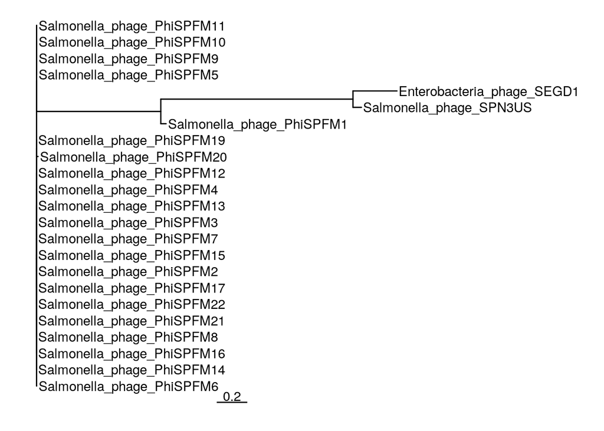

```r
core_snps <- read.tree("/home/fetz/ssd/anisha/gbs/combined/nr_homologues/SalmonellaphageL13_f0_0taxa_algCOG_e1_/spn3us_cluster/23/subset_genomes/snps_ed.tre")
ggtree(core_snps) + geom_tiplab() + geom_treescale(width = 0.2) + xlim(0,3.5)
```

### Phylogenomic tree

##### This tree shows the relationships between the PhiSPFM phages and two similar Enterobacterial phages isolated in different studies, SEGD1 and SPN3US. The tree was built from SNPs taken from codon alignments of 187 core genes shared by all the 23 sequenced SPN3US-like phages. With the exception of PhiSPFM1, the PhiSPFM phages are nearly indistiguishable according to their core genome.

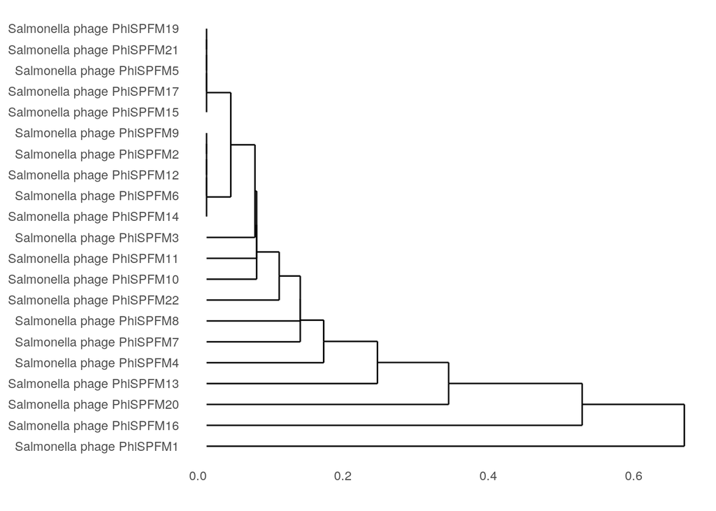

```r
library(ggdendro)
#load the name key for the phages
name_key <- read.table("~/ssd/anisha/phage_names.csv", sep = "\t", header = T)

#gene presence/absence matrix
clusts <- read.table("/home/fetz/ssd/anisha/gbs/combined/nr_homologues/SalmonellaphageL13_f0_0taxa_algCOG_e1_/summary.tab", sep = "\t", quote = "", header = T, colClasses = rep("character",6))[,1:6]

clust.subset <- clusts[grep("Salmonella phage PhiSPFM",clusts$phage_name),]

clust.mat <- matrix(data = 0, nrow = length(unique(clust.subset$phage_name)), ncol = length(unique(clust.subset$cluster_number)), dimnames = list(unique(clust.subset$phage_name), unique(clust.subset$cluster_number)))

for(row in 1:dim(clust.subset)[1]){
  clust.mat[clust.subset[row,'phage_name'],clust.subset[row,'cluster_number']] <- 1
}

clust.diff.mat <- clust.mat[,colSums(clust.mat) < 21]

dist_df <- dist(clust.diff.mat, method = "binary")

hclust_df <- hclust(dist_df)

ggdendrogram(hclust_df, rotate = T)
```

### Dendrogram showing relationships based on accessory gene presence/absence

##### This dendrogram shows the relationships between the PhiSPFM phages according to the presence/absence of accessory genes. Accessory genes are not present in every phage genome and there is greater variance among the accessory genes than the core genes in these phages. This allows for better resolution of the differences between the phages, but does not necessarily encode a phylogenetic signal. For example, phages PhiSPFM19, 21, 5, 17, and 15 share the same exact set of orthologs, as do phages PhiSPFM 9, 2, 12, 6, and 14. However each group differs by a single ortholog. Jaccard distances were calculated based on presence/absence data for 46 accessory genes and hierarchically clustered.

[figure not shown]

### Box-and-whisker plot of D<sub>N</sub>/D<sub>S</sub> ratios

#### This box and whisker plot shows the D<sub>N</sub>/D<sub>S</sub> ratio for all pairwise comparisons of core orthologs from the SPN3US-like phages. The D<sub>N</sub>/D<sub>S</sub> ratios were calculated using codeml. Core phage orthologs within this group seem to mostly be under purifying selection, with most ratios below 1.